# Lab 2: Spatial Analysis and Visualization

Healthcare Access and Equity in Pennsylvania

Author

Wesley Nay

Published

February 23, 2026

## Assignment Overview

**Learning Objectives:** - Apply spatial operations to answer policy-relevant research questions - Integrate census demographic data with spatial analysis - Create publication-quality visualizations and maps - Work with spatial data from multiple sources - Communicate findings effectively for policy audiences

## Part 1: Healthcare Access for Vulnerable Populations

### Research Question

**Which Pennsylvania counties have the highest proportion of vulnerable populations (elderly + low-income) living far from hospitals?**

Your analysis should identify counties that should be priorities for healthcare investment and policy intervention.

### Required Analysis Steps

Complete the following analysis, documenting each step with code and brief explanations:

#### Step 1: Data Collection (5 points)

Load the required spatial data:

**Your Task:**

**Questions to answer:** - How many hospitals are in your dataset?

223 hospitals

- How many census tracts?

3,446 census tracts

- What coordinate reference system is each dataset in?

pa_counties is in NAD83 or EPSG 4269

pa_hospitals is in WGS 84 or EPSF 4326

pa_tracts is in NAD83 or EPSG 4269

#### Step 2: Get Demographic Data

Use `tidycensus` to download tract-level demographic data for Pennsylvania.

**Required variables:** - Total population - Median household income - Population 65 years and over (you may need to sum multiple age categories)

**Your Task:**

```r
# Get demographic data from ACS
#define age variables
age_65plus_vars <- c(
  male_65_66 = "B01001_020",
  male_67_69 = "B01001_021",
  male_70_74 = "B01001_022",
  male_75_79 = "B01001_023",
  male_80_84 = "B01001_024",
  male_85_plus = "B01001_025",
  female_65_66 = "B01001_044",
  female_67_69 = "B01001_045",
  female_70_74 = "B01001_046",
  female_75_79 = "B01001_047",
  female_80_84 = "B01001_048",
  female_85_plus = "B01001_049"
)

# total pop
pa_total_pop <- get_acs(
  geography = "tract",
  state = "PA",
  variables = "B01003_001",
  year = 2023,
  survey = "acs5",
  geometry = FALSE,
   output = "wide"
) %>%
  rename("total_pop" = "B01003_001E",
         "moe" = "B01003_001M")

# median income
pa_med_inc <- get_acs(
  geography = "tract",
  state = "PA",
  variables = "B19013_001",
  year = 2023,
  survey = "acs5",
  geometry = FALSE,
   output = "wide"
) %>%
  rename("median_income" = "B19013_001E",
         "moe" = "B19013_001M") %>%
  select(GEOID,median_income)

# pop 65+
pa_65_plus <- get_acs(
  geography = "tract",
  state = "PA",
  variables = age_65plus_vars,
  year = 2023,
  survey = "acs5",
  geometry = FALSE,
   output = "wide"
)

## sum 65+ columns to get total
pa_65_plus <- pa_65_plus %>%
  mutate(
    pop_65_plus =
      male_65_66E + male_67_69E + male_70_74E + male_75_79E + male_80_84E + male_85_plusE + female_65_66E + female_67_69E + female_70_74E + female_75_79E + female_80_84E + female_85_plusE
  ) %>%
  select(GEOID, pop_65_plus)

# join data
pa_data <- pa_total_pop %>%
  left_join(pa_med_inc, by = "GEOID") %>%
  left_join(pa_65_plus, by = "GEOID")

# separate NAME column into census tract and county; drop state name
pa_data <- pa_data %>%
  separate(NAME, into = c("census_tract", "county_name", "state_name"), sep = "; ")

pa_data <- pa_data %>%
  mutate(
    tract_number = str_remove(census_tract, "Census Tract "),
    county_name = str_remove(county_name, " County")
  ) %>%
  select(-census_tract, -state_name)

# count missing values #| echo: false
sum(is.na(pa_data$median_income))
```

```
[1] 66
```

```r
tibble(
  Measure = "Missing Median Income Values",
  Count = sum(is.na(pa_data$median_income))
) %>%
  kable(
    caption = "Number of Census Tracts with Missing Median Income (ACS 2023 5-Year)"
  )
```

Number of Census Tracts with Missing Median Income (ACS 2023 5-Year)

| Measure | Count |
| --- | --- |
| Missing Median Income Values | 66 |

```r
# pull median income across all PA census tracts #| echo: false
pa_state_income <- get_acs(
  geography = "state",
  state = "PA",
  variables = "B19013_001",
  year = 2023,
  survey = "acs5"
)

# print for viewing
pa_state_income %>%
  transmute(
    State = NAME,
    `Median Household Income` = scales::dollar(estimate)
  ) %>%
  kable(
    caption = "Median Household Income, Pennsylvania (ACS 2023 5-Year)"
  )
```

Median Household Income, Pennsylvania (ACS 2023 5-Year)

| State | Median Household Income |
| --- | --- |
| Pennsylvania | $76,081 |

**Questions to answer:** - What year of ACS data are you using? 2023

- How many tracts have missing income data? 66 tracts have missing income data
- What is the median income across all PA census tracts? $76,081 is the statewide median income

#### Step 3: Define Vulnerable Populations

Identify census tracts with vulnerable populations based on TWO criteria: 1. Low median household income (choose an appropriate threshold) 2. Significant elderly population (choose an appropriate threshold)

**Your Task:**

```r
# create vulnerability thresholds
low_income_threshold <- 76000
high_elder_threshold <- 20

# calculate 65+ proportions for census tracts
pa_data <- pa_data %>%
  mutate(
    perc_65_plus = round((pop_65_plus / total_pop) * 100, 2)
  )

# filter and identify vulnerable tracts
vulnerable_tracts <- pa_data %>%
  filter(median_income < low_income_threshold,
         perc_65_plus >= high_elder_threshold
         )
```

**Questions to answer:** - What income threshold did you choose and why? I chose less than 76,000 as the threshold for low-income tracts because the PA state median income is approximately 76,000,. This measure is quite subjective and arbitrary given that I do not factor in household size or other factors. Depending on the size of the household, $76,000 is likely sufficient for a single-person household but certainly not adequate for a family of four. Moreover, this threshold does not consider cost of living variances across census tracts.

- What elderly population threshold did you choose and why?

I chose equal to or greater than 20% as my threshold for a significant elderly population. According to the U.S. Census Bureau, about 20% of the PA population and about 18% of the national population are 65 or older. Based on this, I know that PA has a greater proportion of aging adults. Again, quite subjectively, I believe that 20% represents a significant proportion of the population to be aging, especially because it is above the national average. If PA’s population is 20% 65 and older, it is important to identify which tracts are skewing the state average higher as the vulnerable tracts.

- How many tracts meet your vulnerability criteria?

834 tracts meet both my vulnerability criteria of BOTH a median income of less than $76,000 and a percentage equal to or greater than 20% of the population as 65 and over.

- What percentage of PA census tracts are considered vulnerable by your definition?

## About 24% of PA census tracts are considered vulnerable by my definition above.

#### Step 4: Calculate Distance to Hospitals

For each vulnerable tract, calculate the distance to the nearest hospital.

**Your Task:**

```r
#make vulnerable tracts spatial
vulnerable_tracts <- vulnerable_tracts %>%
  left_join(
    pa_tracts %>% select(GEOID, geometry),
    by = "GEOID"
  ) %>%
  st_as_sf()

# Transform to appropriate projected CRS |
vulnerable_tracts <- st_transform(vulnerable_tracts, 3365)
pa_hospitals <- st_transform(pa_hospitals, 3365)
pa_counties <- st_transform(pa_counties, 3365)


# centroids of vulnerable tracts
tract_centroids <- st_centroid(vulnerable_tracts)

# distance matrix
distance_matrix <- st_distance(tract_centroids, pa_hospitals)

# distance to nearest hospital per tract
vulnerable_tracts <- vulnerable_tracts %>%
  mutate(
    dist_to_nearest_hosp_ft = apply(distance_matrix, 1, min),
    dist_to_nearest_hosp_miles = dist_to_nearest_hosp_ft / 5280
  )


# sanity check: get hospital names to check work
nearest_hosp_index <- apply(distance_matrix, 1, which.min)

vulnerable_tracts <- vulnerable_tracts %>%
  mutate(
    nearest_hospital_index = nearest_hosp_index,
    nearest_hospital_name = pa_hospitals$FACILITY_N[nearest_hosp_index]  # adjust column name if needed
  )

# calculate average distance
avg_distance <- median(
  vulnerable_tracts$dist_to_nearest_hosp_miles,
  na.rm = TRUE
)

# calculate maximum distance
max_distance <- max(
  vulnerable_tracts$dist_to_nearest_hosp_miles,
  na.rm = TRUE
)

# number of vulnerable tracts more than 15 miles away from the nearest hospital
tracts_over_15 <- sum(
  vulnerable_tracts$dist_to_nearest_hosp_miles > 15,
  na.rm = TRUE
)
```

**Requirements:** - Use an appropriate projected coordinate system for Pennsylvania - Calculate distances in miles - Explain why you chose your projection

**Questions to answer:**

I used CRS 3365 (NAD83) for my calculations because this is the Pennsylvania South (ftUS) projected coordinate reference system, which would make the calculations most precise for the majority of the state of PA.

- What is the average distance to the nearest hospital for vulnerable tracts?

The average (median) distance to the nearest hospital for vulnerable tracts is about 3.96 miles.

- What is the maximum distance?

The maximum distance is about 32.84 miles to the nearest hospital.

- How many vulnerable tracts are more than 15 miles from the nearest hospital?

## There are 49 vulnerable tracts that are more than 15 miles from the nearest hospital.

#### Step 5: Identify Underserved Areas

Define “underserved” as vulnerable tracts that are more than 15 miles from the nearest hospital.

**Your Task:**

```r
# Create underserved variable
# Create underserved indicator
vulnerable_tracts <- vulnerable_tracts %>%
  mutate(
    underserved = dist_to_nearest_hosp_miles > 15
  )

# Count underserved tracts
num_underserved <- sum(vulnerable_tracts$underserved, na.rm = TRUE)

# Percent of vulnerable tracts underserved
percent_underserved <- round(
  (num_underserved / nrow(vulnerable_tracts)) * 100, 2
)
```

**Questions to answer:** - How many tracts are underserved?

49 tracts are underserved.

- What percentage of vulnerable tracts are underserved?

About 5.88% of vulnerable tracts are underserved.

- Does this surprise you? Why or why not?

This does not necessarily surprise me because we are simply using 15 miles away from a hospital as a proxy for underserved tracts. Depending on whether residents in these tracts have access to a vehicle or transit to access these hospitals, 15 miles may be way too far. Additionally, many metro areas in PA like Philadelphia and Pittsburgh have strong hospital coverage.

#### Step 6: Aggregate to County Level

Use spatial joins and aggregation to calculate county-level statistics about vulnerable populations and hospital access.

**Your Task:**

```r
# Spatial join vulnerable tracts to counties
vulnerable_with_county <- st_join(
  vulnerable_tracts,
  pa_counties %>% select(NAME),
  left = TRUE
) %>%
  rename(county = NAME)

# Aggregate county statistics
county_summary <- vulnerable_with_county %>%
  st_drop_geometry() %>%
  group_by(county) %>%
  summarise(
    vulnerable_tracts = n(),
    underserved_tracts = sum(underserved, na.rm = TRUE),
    pct_underserved = round(
      (underserved_tracts / vulnerable_tracts) * 100, 2
    ),
    avg_distance_miles = round(
      mean(dist_to_nearest_hosp_miles, na.rm = TRUE), 2
    ),
    total_vulnerable_pop = sum(pop_65_plus, na.rm = TRUE)
  ) %>%
  arrange(desc(pct_underserved))
```

**Questions to answer:** - Which 5 counties have the highest percentage of underserved vulnerable tracts?

Sullivan, Snyder, Dauphin, Perry, and Pike Counties have the highest percentage of underserved vulnerable tracts.

- Which counties have the most vulnerable people living far from hospitals?

Bradford, Clearfield, Sullivan, Dauphin, and Juniata Counties have the most vulnerable people living far from hospitals.

- Are there any patterns in where underserved counties are located?

## The underserved counties are generally more rural and located in Central PA and in the Appalachian regions of the state. These areas tend to have lower population density, larger geographic distances between towns, and fewer major healthcare systems as opposed to metro areas like Philadelphia. Dauphin County is an outlier to this pattern.

#### Step 7: Create Summary Table

Create a professional table showing the top 10 priority counties for healthcare investment.

**Your Task:**

```r
# Create and format priority counties table
priority_counties <- county_summary %>%
  arrange(desc(pct_underserved), desc(total_vulnerable_pop)) %>%
  slice(1:10)

priority_counties %>%
  mutate(
    total_vulnerable_pop = scales::comma(total_vulnerable_pop),
    pct_underserved = paste0(pct_underserved, "%")
  ) %>%
  kable(
    caption = "Top 10 Priority Pennsylvania Counties for Healthcare Investment Based on Vulnerable Population Access"
  )
```

Top 10 Priority Pennsylvania Counties for Healthcare Investment Based on Vulnerable Population Access

| county | vulnerable_tracts | underserved_tracts | pct_underserved | avg_distance_miles | total_vulnerable_pop |
| --- | --- | --- | --- | --- | --- |
| Sullivan | 10 | 6 | 60% | 17.12 | 8,001 |
| Snyder | 8 | 4 | 50% | 15.16 | 7,790 |
| Dauphin | 13 | 6 | 46.15% | 11.92 | 12,819 |
| Perry | 9 | 4 | 44.44% | 14.24 | 9,406 |
| Pike | 9 | 4 | 44.44% | 16.68 | 5,795 |
| Bradford | 21 | 9 | 42.86% | 13.79 | 16,997 |
| Juniata | 14 | 6 | 42.86% | 13.41 | 12,355 |
| Clinton | 10 | 4 | 40% | 12.74 | 7,312 |
| Cameron | 11 | 4 | 36.36% | 13.05 | 7,166 |
| Wyoming | 12 | 4 | 33.33% | 14.19 | 10,560 |

## Part 2: Comprehensive Visualization

Using the skills from Week 3 (Data Visualization), create publication-quality maps and charts.

### Map 1: County-Level Choropleth

Create a choropleth map showing healthcare access challenges at the county level.

**Your Task:**

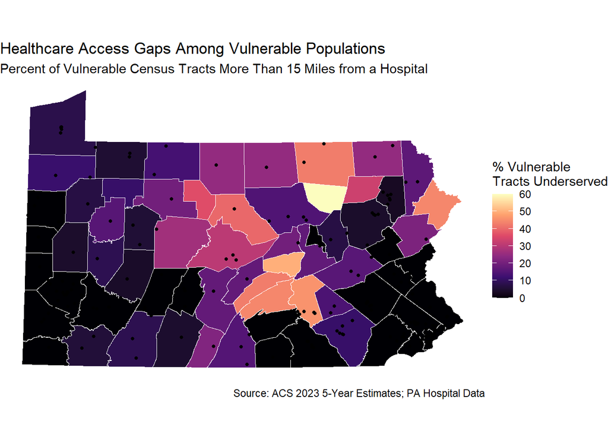

```r
# Create county-level access map
# Join summary back to county geometry
county_map_data <- pa_counties %>%
  left_join(county_summary, by = c("NAME" = "county"))

ggplot() +
  geom_sf(data = county_map_data,
          aes(fill = pct_underserved),
          color = "white") +
  geom_sf(data = pa_hospitals,
          size = 1,
          color = "black") +
  scale_fill_viridis_c(
    option = "magma",
    na.value = "grey90",
    name = "% Vulnerable\nTracts Underserved"
  ) +
  labs(
    title = "Healthcare Access Gaps Among Vulnerable Populations",
    subtitle = "Percent of Vulnerable Census Tracts More Than 15 Miles from a Hospital",
    caption = "Source: ACS 2023 5-Year Estimates; PA Hospital Data"
  ) +
  theme_void()
```

### Map 2: Detailed Vulnerability Map

Create a map highlighting underserved vulnerable tracts.

**Your Task:**

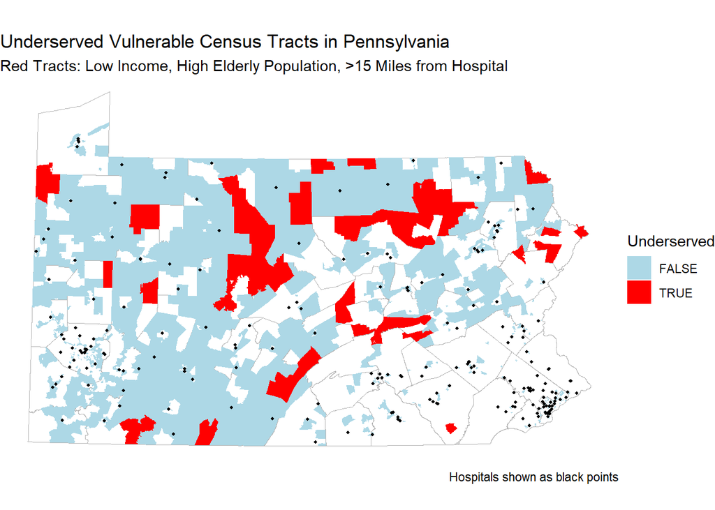

```r
# Create detailed tract-level map
ggplot() +
  geom_sf(data = pa_counties, fill = NA, color = "grey70") +
  geom_sf(data = vulnerable_tracts,
          aes(fill = underserved),
          color = NA) +
  geom_sf(data = pa_hospitals,
          color = "black",
          size = 0.8) +
  scale_fill_manual(
    values = c("FALSE" = "lightblue",
               "TRUE" = "red"),
    name = "Underserved"
  ) +
  labs(
    title = "Underserved Vulnerable Census Tracts in Pennsylvania",
    subtitle = "Red Tracts: Low Income, High Elderly Population, >15 Miles from Hospital",
    caption = "Hospitals shown as black points"
  ) +
  theme_void()
```

### Chart: Distribution Analysis

Create a visualization showing the distribution of distances to hospitals for vulnerable populations.

**Your Task:**

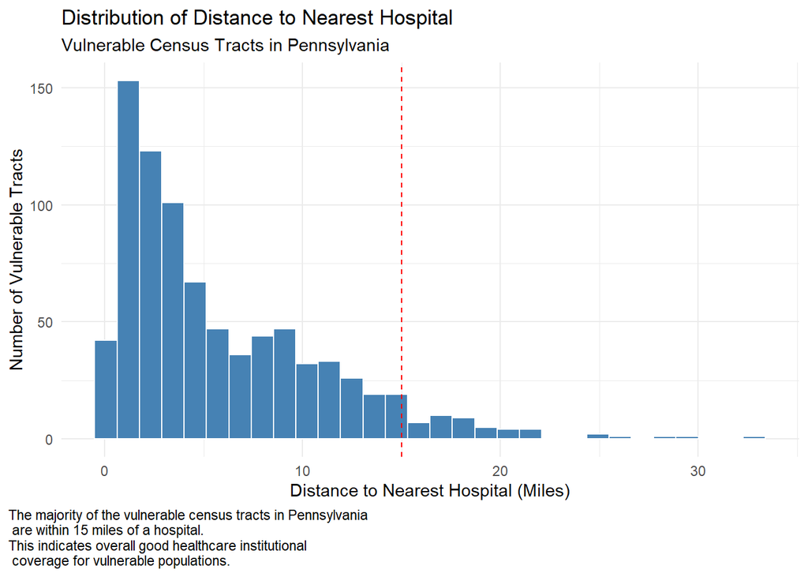

```r
# Create distribution visualization
ggplot(vulnerable_tracts,
       aes(x = dist_to_nearest_hosp_miles)) +
  geom_histogram(
    bins = 30,
    fill = "steelblue",
    color = "white"
  ) +
  geom_vline(
    xintercept = 15,
    linetype = "dashed",
    color = "red"
  ) +
  labs(
    title = "Distribution of Distance to Nearest Hospital",
    subtitle = "Vulnerable Census Tracts in Pennsylvania",
    caption = "The majority of the vulnerable census tracts in Pennsylvania\n are within 15 miles of a hospital. \nThis indicates overall good healthcare institutional\n coverage for vulnerable populations.",
    x = "Distance to Nearest Hospital (Miles)",
    y = "Number of Vulnerable Tracts"
  ) +
  theme_minimal() +
  theme(
  plot.caption = element_text(hjust = 0),
  plot.caption.position = "plot"
)
```

**Suggested chart types:** - Histogram or density plot of distances - Box plot comparing distances across regions - Bar chart of underserved tracts by county - Scatter plot of distance vs. vulnerable population size

**Requirements:** - Clear axes labels with units - Appropriate title - Professional formatting - Brief interpretation (1-2 sentences as a caption or in text)

## Part 3: Bring Your Own Data Analysis

Choose your own additional spatial dataset and conduct a supplementary analysis.

#### Education & Youth Services

**Option A: Educational Desert Analysis** - **Data:** Schools, Libraries, Recreation Centers, Census tracts (child population) - **Question:** “Which neighborhoods lack adequate educational infrastructure for children?” - **Operations:** Buffer schools/libraries (0.5 mile walking distance), identify coverage gaps, overlay with child population density - **Policy relevance:** School district planning, library placement, after-school program siting

### Data Sources

**OpenDataPhilly:** https://opendataphilly.org/datasets/ - Most datasets available as GeoJSON, Shapefile, or CSV with coordinates - Always check the Metadata for a data dictionary of the fields.

**Additional Sources:** - **Pennsylvania Open Data:** https://data.pa.gov/ - **Census Bureau (via tidycensus):** Demographics, economic indicators, commute patterns - **TIGER/Line (via tigris):** Geographic boundaries

### Your Analysis

**Your Task:**

1. **Find and load additional data**
   - Document your data source
   - Check and standardize the CRS
   - Provide basic summary statistics

```r
# Load your additional dataset
phl_schools <- st_read("data/Schools/Schools.shp")

# transform into correct projection
phl_schools <- st_transform(phl_schools, 3365)

# summary stats
nrow(phl_schools) # number of schools
```

[output not shown]

**Questions to answer:** - What dataset did you choose and why?

I chose the Philadelphia Schools (points) dataset to analyze access to educational infrastructure for children in Philadelphia. Youth are critical to the future of cities and it is important for planners to include them in our analysis to inform policy.

- What is the data source and date?

The data source is the City of Philadelphia’s Open Data Portal. The dataset is schools (geometry type is point), and it “includes public schools, charter schools, many private schools, school annexes, and athletic fields and facilities” (OpenDataPhilly).

- How many features does it contain?

The dataset contains 490 features (points).

- What CRS is it in? Did you need to transform it?

The dataset was originally in EPSG 4326 (WGS 84), and I transformed it to EPSG 3365, which is a CRS that is more suitable for calculations and analysis. EPSG 3365 is the same CRS I use earlier in this analysis.

2. **Pose a research question**

Which Philadelphia neighborhoods with high child populations lack nearby access to public schools?

3. **Conduct spatial analysis**

Use at least TWO spatial operations to answer your research question.

**Required operations (choose 2+):** - Buffers - Spatial joins - Spatial filtering with predicates - Distance calculations - Intersections or unions - Point-in-polygon aggregation

**Your Task:**

[figure not shown]

```r
# Your spatial analysis

# 0.5 mile buffer in feet for EPSG:3365
buffer_dist <- 2640

school_buffer <- st_buffer(phl_schools, dist = buffer_dist)

# Merge all school buffers into a single coverage layer
edu_buffers <- st_union(school_buffer)

# filter pa tracts to philly
philly_tracts <- pa_tracts %>%
  filter(COUNTYFP == "101")  # 101 = Philadelphia County FIPS

# transform CRS
philly_tracts <- st_transform(philly_tracts, 3365)

# Compute coverage as a proportion (numeric)
philly_tracts$coverage_pct <- as.numeric(
  st_area(st_intersection(philly_tracts, edu_buffers)) / st_area(philly_tracts)
)

# filter educational deserts
edu_deserts <- philly_tracts %>%
  filter(coverage_pct < 0.25)

# Summary statistics
kable(data.frame(
  Metric = c("Total Philadelphia Tracts", "Educational Desert Tracts"),
  Count = c(nrow(philly_tracts), nrow(edu_deserts))
))


# map
ggplot() +
  geom_sf(data = philly_tracts, fill = "grey90", color = "white") +
  geom_sf(data = edu_deserts, fill = "red", alpha = 0.6) +
  geom_sf(data = phl_schools, color = "blue", size = 2) +
  labs(
    title = "Educational Deserts in Philadelphia",
    subtitle = "Census tracts with low 0.5-mile access to public schools",
    caption = "Red = educational deserts; Blue points = schools",
    x = "Distance East (miles)",
    y = "Distance North (miles)"
  ) +
  scale_x_continuous(labels = function(x) round(x / 5280, 1)) +
  scale_y_continuous(labels = function(y) round(y / 5280, 1)) +
  theme_minimal() +
  theme(
    plot.caption = element_text(hjust = 0)
  )
```

[output not shown]

**Analysis requirements:** - Clear code comments explaining each step - Appropriate CRS transformations - Summary statistics or counts - At least one map showing your findings - Brief interpretation of results (3-5 sentences)